# Rangewide Analysis

Andres N. Rosales

2025-01-24

# Candidate Models

**Prediction 1**

Breeding regions declining in trend will be correlated with low landscape heterogeneity and simplified agricultural landscapes.

$Trend = Δ SHDI + Δ Edge Density + Δ Cropland + (1 | Location)$

**Prediction 2**

Greater landscape heterogeneity will lower the negative effects of landscape simplification on breeding trends. “Is the effect of landscape diversity on Upland Sandpiper population dynamics dependent on the degree of simplification?”

$Trend = Δ SHDI + Δ Cropland + Δ SHDI * Δ Cropland + (1 | Location)$

**Prediction 3**

Forage agriculture and grasslands are associated with positive trends and high abundance. “How are trends in forage agriculture and grasslands associated with trends and abundance of Upland Sandpiper?”

$Trend = Δ Forage Ag + Δ Grassland + (1 | Location)$

“Does configuration of forage and grassland habitats influence their association with trends and abundance

$Trend = Δ Forage Agriculture * Δ Forage Ag LPI + Δ Grassland * Δ Grassland LPI + (1 | Location)$

**Prediction 4**

Trends decline or become more variable with increasing distance from the core breeding range. Conversely, trends will be more stable near the core breeding region.

$Trend = Periphery + (1 | Location)$

**Prediction 5**

Geographical variation in abundance is driven by marginal habitat at the periphery.

$Trend = Periphery + Δ SHDI + Δ Cropland + (1 | Location) + (1| Year)$

# Response Distribution

Distribution of trend response variable.

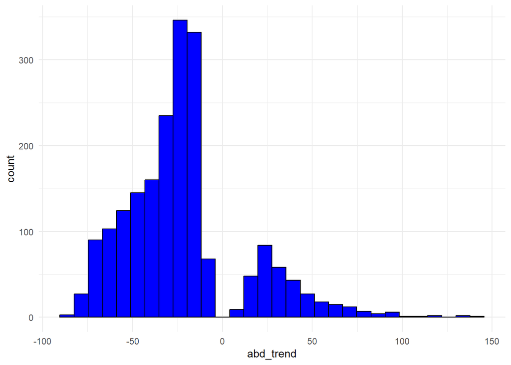

```r
ggplot(upsabuff, aes(x = abd_trend)) +
  geom_histogram(bins = 30, fill = "blue", color = "black") +
  theme_minimal()
```

Almost follows a normal distribution, but without trends that are zero (stable) we observe biomodal. I could possibly look into adding a categorical variable indicating increase or decrease. I need to explore this more…

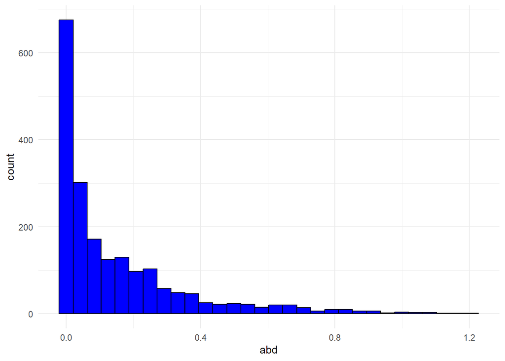

```r
#Distribution of abundance response variable.
ggplot(upsabuff, aes(x = abd)) +
  geom_histogram(bins = 30, fill = "blue", color = "black") +
  theme_minimal()
```

Distribution of abundance estimates.

# Predictor relationships

Correlation matric before aggregating predictors.

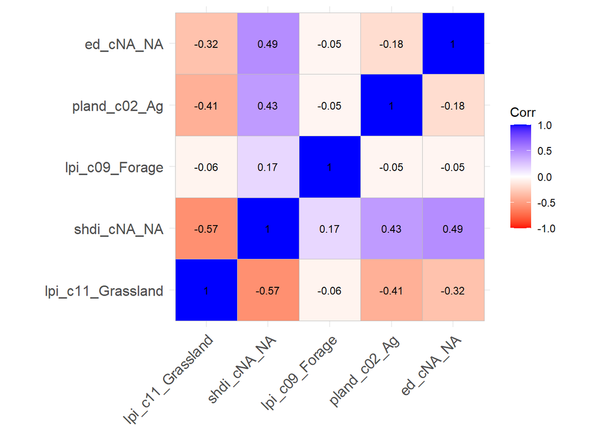

```r
library(ggcorrplot)
# List of predictors to include
predictors <- c(
   "lpi_c11_Grassland", "shdi_cNA_NA", "lpi_c09_Forage", "pland_c02_Ag", "ed_cNA_NA"
)

# Filter dataset
filtered_data <- all_lsm %>%
  dplyr::select(all_of(predictors))

# Compute correlation matrix
cor_matrix <- cor(filtered_data, use = "complete.obs", method = "pearson")

# Visualize the correlation matrix
ggcorrplot(cor_matrix, lab = TRUE, lab_size = 3, colors = c("red", "white", "blue"))
```

I still need to determine a pearsons correlation coefficient threshold to report. Some literature has used 0.7 and I will go with that for now. I still need to develop a better backing for this and if this is something I will continue to use going forward…

## Shannon Diversity Index

I want to use the slope of a linear regression for SHDI ~ year for every location as a proxy for change in SHDI. I will need to confirm SHDI changes in linearly. fit lm and gam and compare fit for slope of SHDI as explanatory predictor

```r
shdi_lmm <- lmer(shdi_cNA_NA ~ year + (1|srd_id), data = all_lsm)
summary(shdi_lmm)
```

```
## Linear mixed model fit by REML ['lmerMod']
## Formula: shdi_cNA_NA ~ year + (1 | srd_id)
##    Data: all_lsm
##
## REML criterion at convergence: -34837.1
##
## Scaled residuals:
##      Min       1Q   Median       3Q      Max
## -14.0486  -0.4342  -0.0162   0.4080  10.1691
##
## Random effects:
##  Groups   Name        Variance Std.Dev.
##  srd_id   (Intercept) 0.149392 0.38651
##  Residual             0.007152 0.08457
## Number of obs: 21681, groups:  srd_id, 1971
##
## Fixed effects:
##               Estimate Std. Error t value
## (Intercept) -8.9275736  0.3664480  -24.36
## year         0.0051451  0.0001816   28.33
##
## Correlation of Fixed Effects:
##      (Intr)
## year -1.000
```

```r
shdi_gamm <- gam(shdi_cNA_NA ~ s(year, k=10) + srd_id, method="REML", data = all_lsm)
summary(shdi_gamm)
```

```
##
## Family: gaussian
## Link function: identity
##
## Formula:
## shdi_cNA_NA ~ s(year, k = 10) + srd_id
##
## Parametric coefficients:
##               Estimate Std. Error t value Pr(>|t|)
## (Intercept)  2.443e+00  2.672e-02   91.42   <2e-16 ***
## srd_id      -3.503e-06  9.382e-08  -37.33   <2e-16 ***
## ---
## Signif. codes:  0 '***' 0.001 '**' 0.01 '*' 0.05 '.' 0.1 ' ' 1
##
## Approximate significance of smooth terms:
##           edf Ref.df     F p-value
## s(year) 4.291  5.282 12.09  <2e-16 ***
## ---
## Signif. codes:  0 '***' 0.001 '**' 0.01 '*' 0.05 '.' 0.1 ' ' 1
##
## R-sq.(adj) =  0.063   Deviance explained = 6.32%
## -REML = 9997.3  Scale est. = 0.14687   n = 21681
```

```r
AIC(shdi_lmm, shdi_gamm)
```

```
##                 df       AIC
## shdi_lmm  4.000000 -34829.10
## shdi_gamm 8.281729  19949.43
```

Big difference in AIC values when comparing GAM and lm model. the relationships of each location likely follow a linear relationship over years, allowing it to be representative of the change in diversity over time.

Calculate change in SHDI using linear regression. THis will be used as a predictor representing the change in diversity over the trend period

```r
#Slope and intercept
shdi_slopes <- all_lsm %>%
  group_by(srd_id) %>%
  summarize(
    shdi_slope = coef(lm(shdi_cNA_NA ~ year))[2],
    shdi_intercept = coef(lm(shdi_cNA_NA ~ year))[1]
  )

upsa_trd <- shdi_slopes %>%
  left_join(upsa_trd, by = c("srd_id"))
```

add mean and standard deviation of shdi for each location

```r
#Mean
mean_shdi <- all_lsm %>%
  group_by(srd_id) %>%
  summarize(mean_shdi = mean(shdi_cNA_NA, na.rm = TRUE))
upsa_trd <- mean_shdi %>%
  left_join(upsa_trd, by = "srd_id")
#Standard Dev
sd_shdi <- all_lsm %>%
  group_by(srd_id) %>%
  summarize(sd_shdi = sd(shdi_cNA_NA, na.rm = TRUE))

upsa_trd <- sd_shdi %>%
  left_join(upsa_trd, by = "srd_id")
```

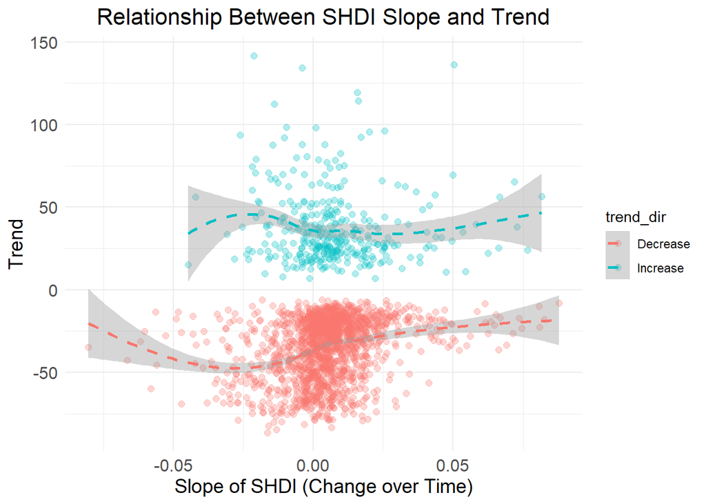

```r
ggplot(upsa_trd, aes(x = shdi_slope, y = abd_trend, color = trend_dir)) +
  geom_point( alpha = 0.3, size = 2) +
  geom_smooth(method = "loess",  se = TRUE, linetype = "dashed") +
  labs(
    title = "Relationship Between SHDI Slope and Trend",
    x = "Slope of SHDI (Change over Time)",
    y = "Trend"
  ) +
  theme_minimal() +
  theme(
    plot.title = element_text(hjust = 0.5, size = 16),
    axis.title = element_text(size = 14),
    axis.text = element_text(size = 12)
  )
```

Figure reveals mostly linear with some deviation along the edges. Test lm and gam model to determine best fit.

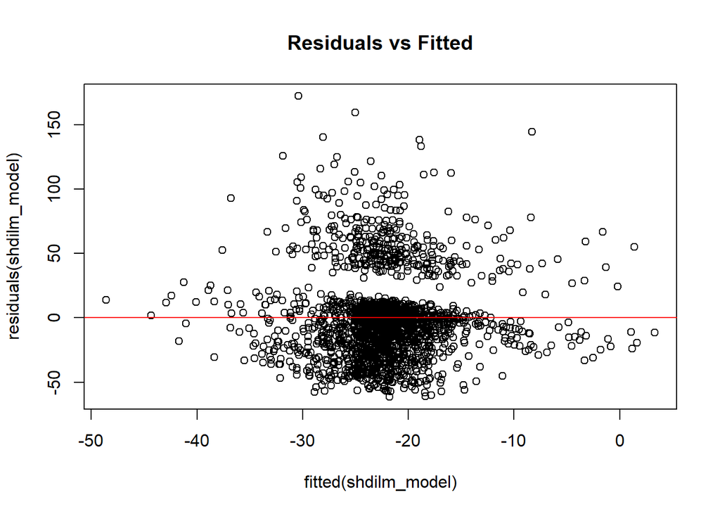

```r
shdilm_model <- lm(abd_trend ~ shdi_slope, data = upsa_trd)
plot(fitted(shdilm_model), residuals(shdilm_model), main = "Residuals vs Fitted")
abline(h = 0, col = "red")
```

```r
shdigam_model <- gam(abd_trend ~ s(shdi_slope), data = upsa_trd)
summary(shdilm_model)
```

```
##
## Call:
## lm(formula = abd_trend ~ shdi_slope, data = upsa_trd)
##
## Residuals:
##     Min      1Q  Median      3Q     Max
## -61.388 -20.679  -3.738   7.770 172.118
##
## Coefficients:
##             Estimate Std. Error t value Pr(>|t|)
## (Intercept) -23.7973     0.7742 -30.738  < 2e-16 ***
## shdi_slope  308.4663    44.9874   6.857  9.4e-12 ***
## ---
## Signif. codes:  0 '***' 0.001 '**' 0.01 '*' 0.05 '.' 0.1 ' ' 1
##
## Residual standard error: 32.8 on 1969 degrees of freedom
## Multiple R-squared:  0.02332,    Adjusted R-squared:  0.02282
## F-statistic: 47.01 on 1 and 1969 DF,  p-value: 9.396e-12
```

```r
summary(shdigam_model)
```

```
##
## Family: gaussian
## Link function: identity
##
## Formula:
## abd_trend ~ s(shdi_slope)
##
## Parametric coefficients:
##             Estimate Std. Error t value Pr(>|t|)
## (Intercept) -22.2102     0.7379   -30.1   <2e-16 ***
## ---
## Signif. codes:  0 '***' 0.001 '**' 0.01 '*' 0.05 '.' 0.1 ' ' 1
##
## Approximate significance of smooth terms:
##                 edf Ref.df     F p-value
## s(shdi_slope) 2.633  3.388 15.13  <2e-16 ***
## ---
## Signif. codes:  0 '***' 0.001 '**' 0.01 '*' 0.05 '.' 0.1 ' ' 1
##
## R-sq.(adj) =  0.0252   Deviance explained = 2.65%
## GCV = 1075.1  Scale est. = 1073.1    n = 1971
```

```r
# Compare lm and gam
AIC(shdilm_model, shdigam_model)
```

```
##                    df      AIC
## shdilm_model  3.00000 19356.62
## shdigam_model 4.63294 19353.40
```

Slight improvement of fit with the GAM model. However, since it is small it might be ok to assume linear relationship.

## Landscape Simplification

calculate slope of landscape simplification over 11 years

```r
simp_slopes <- all_lsm %>%
  group_by(srd_id) %>%
  summarize(
    simp_slope = coef(lm(pland_c02_Ag ~ year))[2],
    simp_intercept = coef(lm(pland_c02_Ag ~ year))[1]
  )

upsa_trd <- simp_slopes %>%
  left_join(upsa_trd, by = c("srd_id"))
```

```r
#Mean
mean_simp <- all_lsm %>%
  group_by(srd_id) %>%
  summarize(mean_simp = mean(pland_c02_Ag, na.rm = TRUE))
upsa_trd <- mean_simp %>%
  left_join(upsa_trd, by = "srd_id")
```

plot simplification slope against trend

[figure not shown]

```r
ggplot(upsa_trd, aes(x = simp_slope, y = abd_trend, color = trend_dir)) +
  geom_point( alpha = 0.3, size = 2) +
  geom_smooth(method = "loess",  se = TRUE, linetype = "dashed") +
  labs(
    title = "Relationship Between SHDI Slope and Trend",
    x = "Slope of SHDI (Change over Time)",
    y = "Trend"
  ) +
  theme_minimal() +
  theme(
    plot.title = element_text(hjust = 0.5, size = 16),
    axis.title = element_text(size = 14),
    axis.text = element_text(size = 12)
  )
```

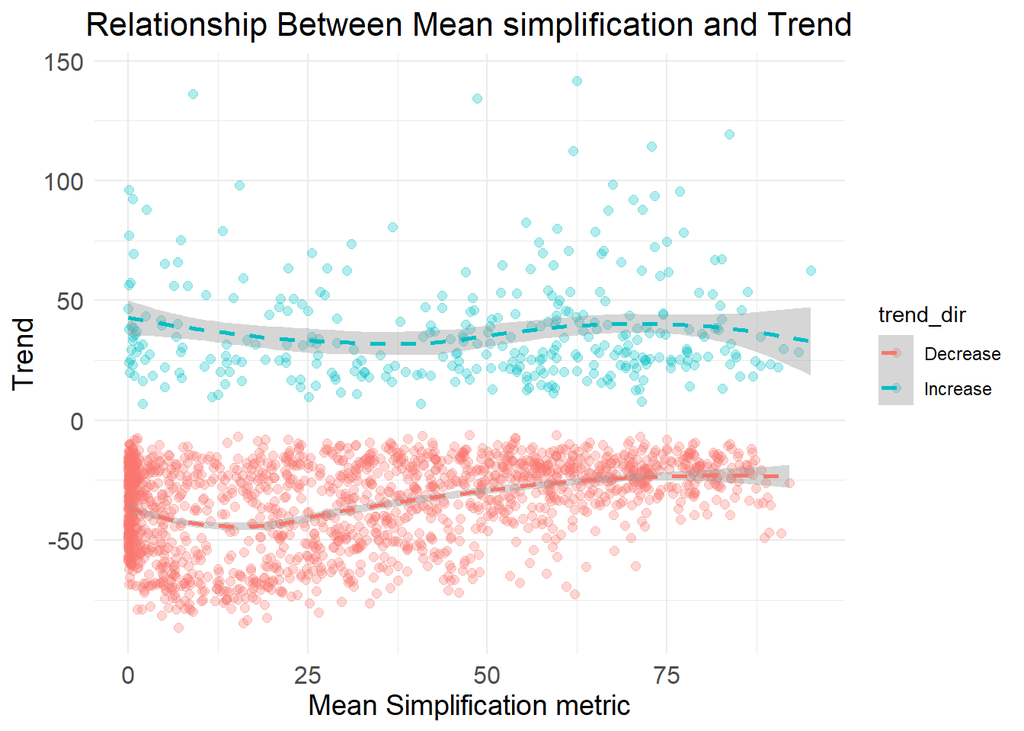

```r
ggplot(upsa_trd, aes(x = mean_simp, y = abd_trend, color = trend_dir)) +
  geom_point( alpha = 0.3, size = 2) +
  geom_smooth(method = "loess",  se = TRUE, linetype = "dashed") +
  labs(
    title = "Relationship Between Mean simplification and Trend",
    x = "Mean Simplification metric",
    y = "Trend"
  ) +
  theme_minimal() +
  theme(
    plot.title = element_text(hjust = 0.5, size = 16),
    axis.title = element_text(size = 14),
    axis.text = element_text(size = 12)
  )
```

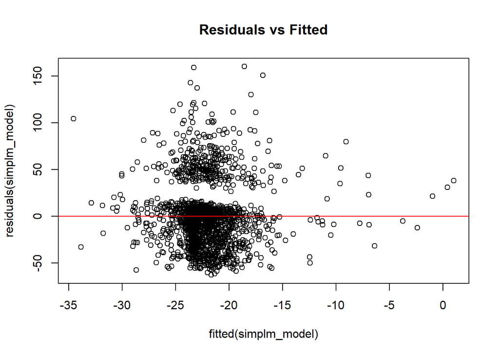

```r
simplm_model <- lm(abd_trend ~ simp_slope, data = upsa_trd)
plot(fitted(simplm_model), residuals(simplm_model), main = "Residuals vs Fitted")
abline(h = 0, col = "red")
```

```r
simpgam_model <- gam(abd_trend ~ s(simp_slope), data = upsa_trd)
summary(simplm_model)
```

```
##
## Call:
## lm(formula = abd_trend ~ simp_slope, data = upsa_trd)
##
## Residuals:
##     Min      1Q  Median      3Q     Max
## -62.918 -21.016  -2.607   8.113 160.319
##
## Coefficients:
##             Estimate Std. Error t value Pr(>|t|)
## (Intercept) -23.4372     0.8155 -28.740  < 2e-16 ***
## simp_slope    5.4440     1.4719   3.699 0.000223 ***
## ---
## Signif. codes:  0 '***' 0.001 '**' 0.01 '*' 0.05 '.' 0.1 ' ' 1
##
## Residual standard error: 33.07 on 1969 degrees of freedom
## Multiple R-squared:  0.0069, Adjusted R-squared:  0.006395
## F-statistic: 13.68 on 1 and 1969 DF,  p-value: 0.0002227
```

```r
summary(simpgam_model)
```

```
##
## Family: gaussian
## Link function: identity
##
## Formula:
## abd_trend ~ s(simp_slope)
##
## Parametric coefficients:
##             Estimate Std. Error t value Pr(>|t|)
## (Intercept) -22.2102     0.7428   -29.9   <2e-16 ***
## ---
## Signif. codes:  0 '***' 0.001 '**' 0.01 '*' 0.05 '.' 0.1 ' ' 1
##
## Approximate significance of smooth terms:
##                 edf Ref.df     F  p-value
## s(simp_slope) 2.977  3.812 6.359 7.28e-05 ***
## ---
## Signif. codes:  0 '***' 0.001 '**' 0.01 '*' 0.05 '.' 0.1 ' ' 1
##
## R-sq.(adj) =  0.0122   Deviance explained = 1.37%
## GCV = 1089.7  Scale est. = 1087.5    n = 1971
```

```r
# Compare lm and gam
AIC(simplm_model, simpgam_model)
```

```
##                    df      AIC
## simplm_model  3.00000 19389.49
## simpgam_model 4.97683 19379.94
```

## LPI Grassland

calculate the slope and average LPI for each location

```r
#Slope
GLPI_slopes <- all_lsm %>%
  group_by(srd_id) %>%
  summarize(
    GLPI_slope = coef(lm(lpi_c11_Grassland ~ year))[2],
    GLPI_intercept = coef(lm(lpi_c11_Grassland ~ year))[1]
  )
upsa_trd <- GLPI_slopes %>%
  left_join(upsa_trd, by = c("srd_id"))

#Mean
mean_GLPI <- all_lsm %>%
  group_by(srd_id) %>%
  summarize(mean_GLPI = mean(lpi_c11_Grassland, na.rm = TRUE))
upsa_trd <- mean_GLPI %>%
  left_join(upsa_trd, by = "srd_id")
```

Plot trend ~ slope and trend ~ Mean

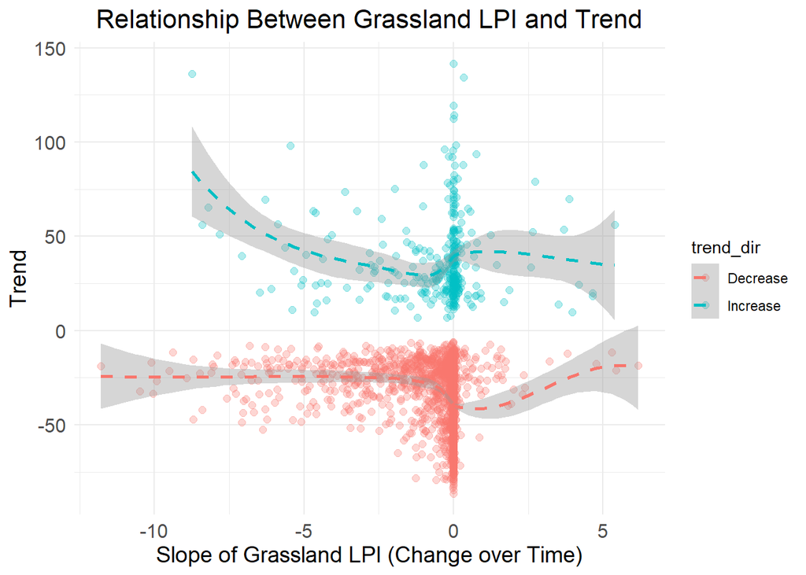

```r
ggplot(upsa_trd, aes(x = GLPI_slope, y = abd_trend, color = trend_dir)) +
  geom_point(alpha = 0.3, size = 2) +
  geom_smooth(method = "loess", se = TRUE, linetype = "dashed") +
  labs(
    title = "Relationship Between Grassland LPI and Trend",
    x = "Slope of Grassland LPI (Change over Time)",
    y = "Trend"
  ) +
  theme_minimal() +
  theme(
    plot.title = element_text(hjust = 0.5, size = 16),
    axis.title = element_text(size = 14),
    axis.text = element_text(size = 12)
  )
```

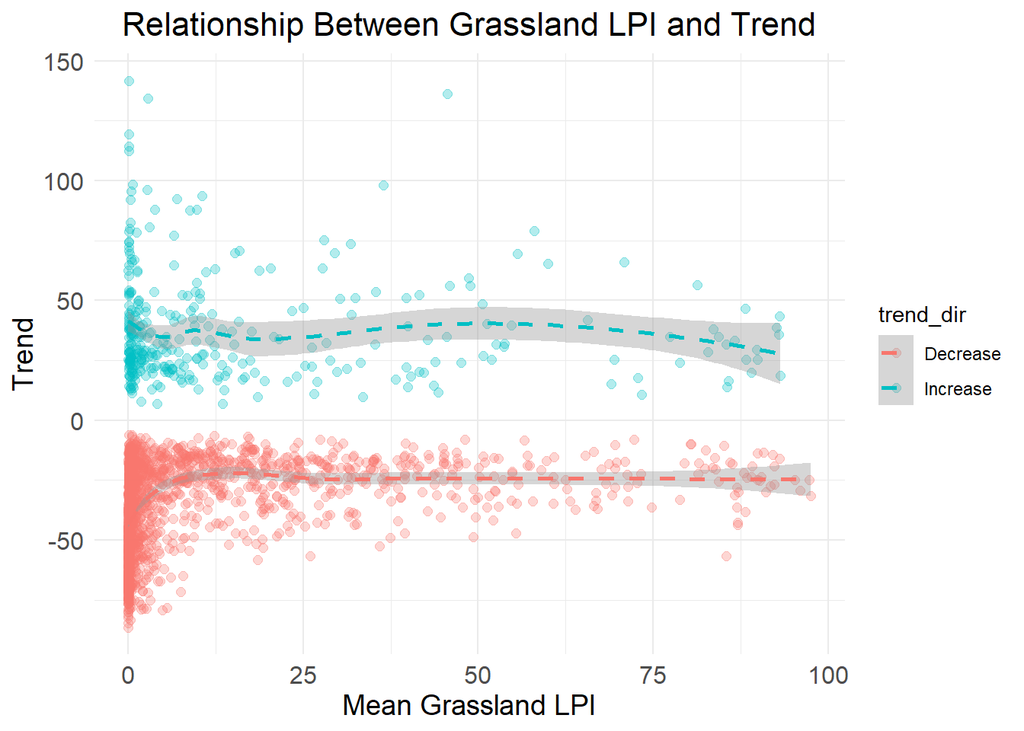

```r
ggplot(upsa_trd, aes(x = mean_GLPI, y = abd_trend, color = trend_dir)) +
  geom_point( alpha = 0.3, size = 2) +
  geom_smooth(method = "loess", se = TRUE, linetype = "dashed") +
  labs(
    title = "Relationship Between Grassland LPI and Trend",
    x = "Mean Grassland LPI",
    y = "Trend"
  ) +
  theme_minimal() +
  theme(
    plot.title = element_text(hjust = 0.5, size = 16),
    axis.title = element_text(size = 14),
    axis.text = element_text(size = 12)
  )
```

## LPI Forage

calculate the slope and average LPI for each location

```r
#Slope
FLPI_slopes <- all_lsm %>%
  group_by(srd_id) %>%
  summarize(
    FLPI_slope = coef(lm(lpi_c09_Forage ~ year))[2],
    FLPI_intercept = coef(lm(lpi_c09_Forage ~ year))[1]
  )
upsa_trd <- FLPI_slopes %>%
  left_join(upsa_trd, by = c("srd_id"))

#Mean
mean_FLPI <- all_lsm %>%
  group_by(srd_id) %>%
  summarize(mean_FLPI = mean(lpi_c09_Forage, na.rm = TRUE))
upsa_trd <- mean_FLPI %>%
  left_join(upsa_trd, by = "srd_id")
```

Plot trend ~ slope and trend ~ Mean

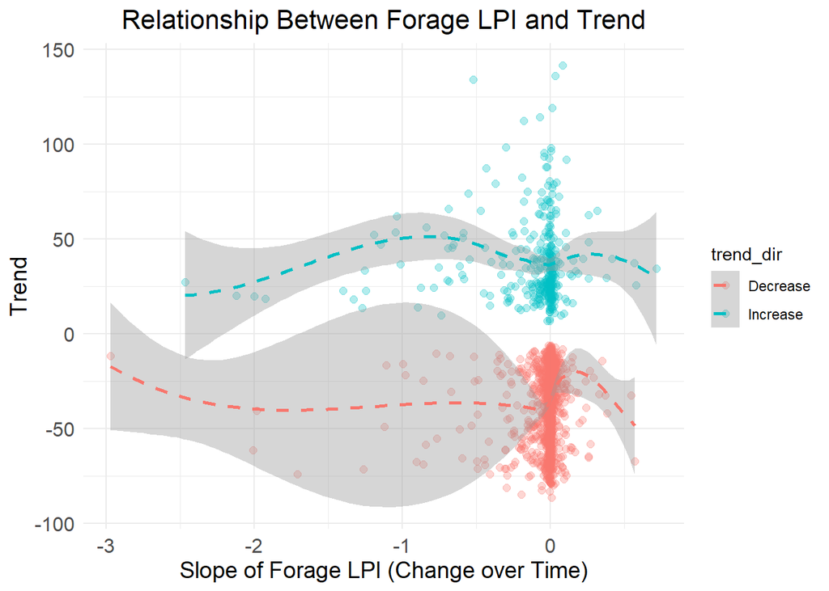

```r
ggplot(upsa_trd, aes(x = FLPI_slope, y = abd_trend, color = trend_dir)) +
  geom_point( alpha = 0.3, size = 2) +
  geom_smooth(method = "loess",  se = TRUE, linetype = "dashed") +
  labs(
    title = "Relationship Between Forage LPI and Trend",
    x = "Slope of Forage LPI (Change over Time)",
    y = "Trend"
  ) +
  theme_minimal() +
  theme(
    plot.title = element_text(hjust = 0.5, size = 16),
    axis.title = element_text(size = 14),
    axis.text = element_text(size = 12)
  )
```

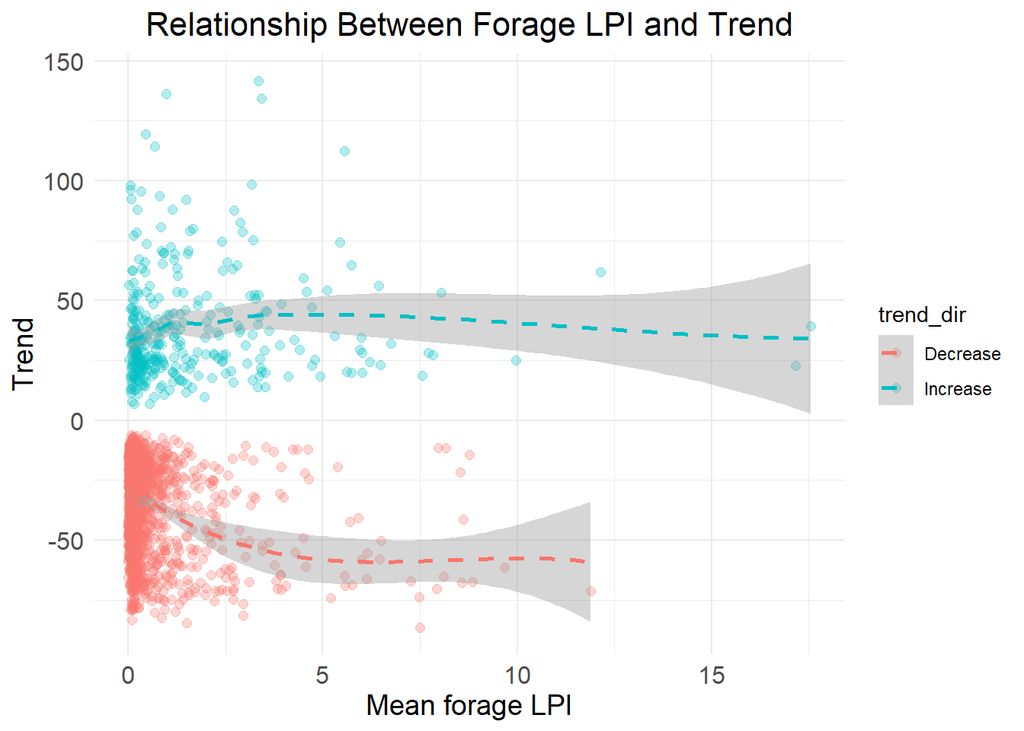

```r
ggplot(upsa_trd, aes(x = mean_FLPI, y = abd_trend, color= trend_dir)) +
  geom_point( alpha = 0.3, size = 2) +
  geom_smooth(method = "loess",  se = TRUE, linetype = "dashed") +
  labs(
    title = "Relationship Between Forage LPI and Trend",
    x = "Mean forage LPI",
    y = "Trend"
  ) +
  theme_minimal() +
  theme(
    plot.title = element_text(hjust = 0.5, size = 16),
    axis.title = element_text(size = 14),
    axis.text = element_text(size = 12)
  )
```

## Edge Density

```r
#Slope
ED_slopes <- all_lsm %>%
  group_by(srd_id) %>%
  summarize(
    ED_slope = coef(lm(ed_cNA_NA ~ year))[2],
    ED_intercept = coef(lm(ed_cNA_NA ~ year))[1]
  )
upsa_trd <- ED_slopes %>%
  left_join(upsa_trd, by = c("srd_id"))

#Mean
mean_ED <- all_lsm %>%
  group_by(srd_id) %>%
  summarize(mean_ED = mean(ed_cNA_NA, na.rm = TRUE))
upsa_trd <- mean_ED %>%
  left_join(upsa_trd, by = "srd_id")
```

Plot trend ~ slope and trend ~ Mean

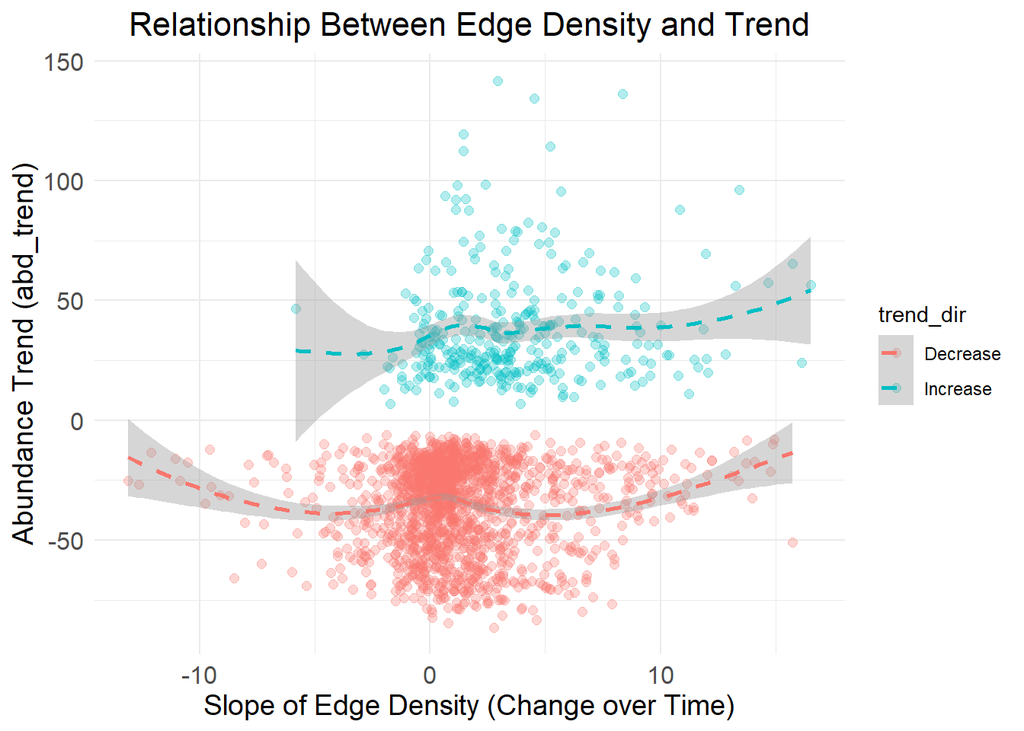

```r
ggplot(upsa_trd, aes(x = ED_slope, y = abd_trend, color = trend_dir)) +
  geom_point( alpha = 0.3, size = 2) +
  geom_smooth(method = "loess", se = TRUE, linetype = "dashed") +
  labs(
    title = "Relationship Between Edge Density and Trend",
    x = "Slope of Edge Density (Change over Time)",
    y = "Abundance Trend (abd_trend)"
  ) +
  theme_minimal() +
  theme(
    plot.title = element_text(hjust = 0.5, size = 16),
    axis.title = element_text(size = 14),
    axis.text = element_text(size = 12)
  )
```

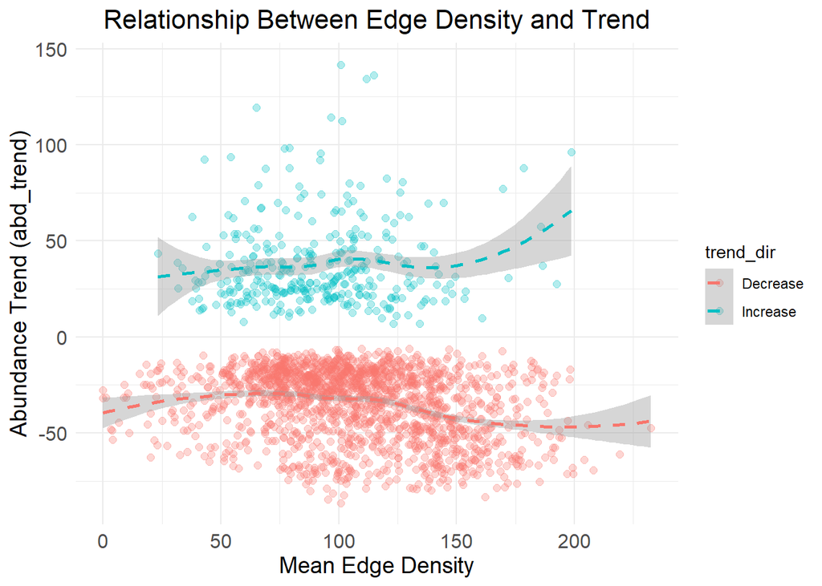

```r
ggplot(upsa_trd, aes(x = mean_ED, y = abd_trend, color = trend_dir)) +
  geom_point( alpha = 0.3, size = 2) +
  geom_smooth(method = "loess",  se = TRUE, linetype = "dashed") +
  labs(
    title = "Relationship Between Edge Density and Trend",
    x = "Mean Edge Density",
    y = "Abundance Trend (abd_trend)"
  ) +
  theme_minimal() +
  theme(
    plot.title = element_text(hjust = 0.5, size = 16),
    axis.title = element_text(size = 14),
    axis.text = element_text(size = 12)
  )
```

### Correlation matrix matrix of relationships / distribution of response and explanatory variables after aggregating

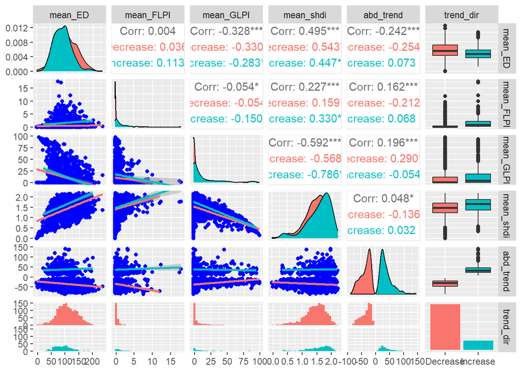

```r
upsa_trd$trend_dir <- ifelse(upsa_trd$abd_trend >0, "Increase", "Decrease")


agg_mean_predictors <- upsa_trd[,c("mean_ED","mean_FLPI","mean_GLPI",  "mean_shdi",  "abd_trend", "trend_dir")]

agg_slope_predictors <- upsa_trd[,c("ED_slope","FLPI_slope", "GLPI_slope", "simp_slope",  "shdi_slope", "abd_trend", "trend_dir")]

#aggregated_predictors <- upsa_trd[,c("mean_ED","ED_slope","mean_FLPI","FLPI_slope","mean_GLPI", "GLPI_slope", "simp_slope", "mean_shdi", "shdi_slope", "abd_trend", "trend_dir")]

#Average
ggpairs(agg_mean_predictors, ggplot2::aes(colour = trend_dir), lower = list(continuous = wrap("smooth", colour = "blue")))
```

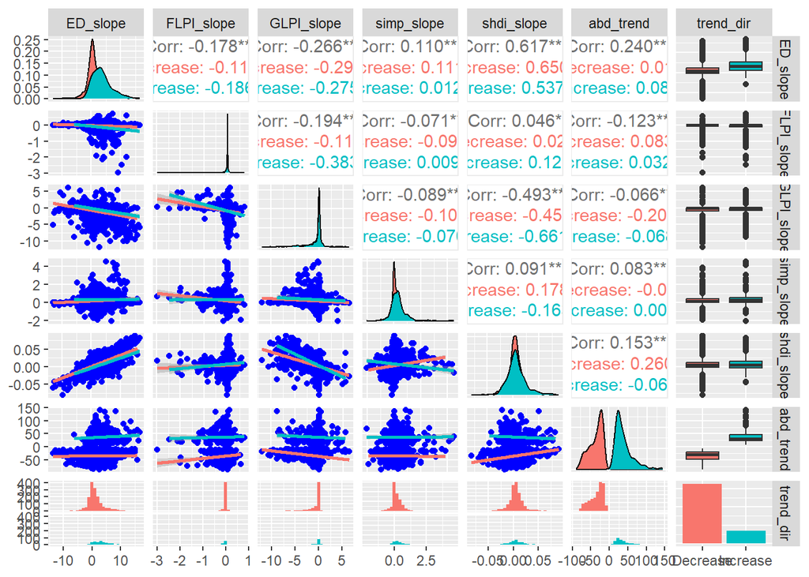

```r
#Slope
ggpairs(agg_slope_predictors, ggplot2::aes(colour = trend_dir), lower = list(continuous = wrap("smooth", colour = "blue")))
```

```r
names(upsa_trd)
```

```
##  [1] "srd_id"          "mean_ED"         "ED_slope"        "ED_intercept"
##  [5] "mean_FLPI"       "FLPI_slope"      "FLPI_intercept"  "mean_GLPI"
##  [9] "GLPI_slope"      "GLPI_intercept"  "mean_simp"       "simp_slope"
## [13] "simp_intercept"  "sd_shdi"         "mean_shdi"       "shdi_slope"
## [17] "shdi_intercept"  "longitude"       "latitude"        "abd"
## [21] "abd_ppy"         "abd_ppy_lower"   "abd_ppy_upper"   "abd_ppy_nonzero"
## [25] "abd_trend"       "abd_trend_lower" "abd_trend_upper" "trend_dir"
```

# Model Runs

Current work in progress…

I have the data frame and predictors set up to be able to run models.

I need to determine which predictors I will use in candidate models (mean vs slope). Also, I need to determine a strategy for how I will model.(How can I include abundance, spatial dependencies?, error structure?)

Model prediction 1 using gam with smoothed interaction of location

```r
P1gam <- gam(abd_trend ~ s(mean_shdi) + s(mean_ED) + s(mean_simp) + s(longitude, latitude), data = upsa_trd, method = "REML")
summary(P1gam)
```

```
##
## Family: gaussian
## Link function: identity
##
## Formula:
## abd_trend ~ s(mean_shdi) + s(mean_ED) + s(mean_simp) + s(longitude,
##     latitude)
##
## Parametric coefficients:
##             Estimate Std. Error t value Pr(>|t|)
## (Intercept) -22.2102     0.4667  -47.59   <2e-16 ***
## ---
## Signif. codes:  0 '***' 0.001 '**' 0.01 '*' 0.05 '.' 0.1 ' ' 1
##
## Approximate significance of smooth terms:
##                          edf Ref.df      F  p-value
## s(mean_shdi)           1.699  2.129  8.493 0.000179 ***
## s(mean_ED)             3.079  3.930  1.012 0.389588
## s(mean_simp)           2.482  3.173 54.497  < 2e-16 ***
## s(longitude,latitude) 24.757 27.890 82.066  < 2e-16 ***
## ---
## Signif. codes:  0 '***' 0.001 '**' 0.01 '*' 0.05 '.' 0.1 ' ' 1
##
## R-sq.(adj) =   0.61   Deviance explained = 61.6%
## -REML = 8803.4  Scale est. = 429.32    n = 1971
```

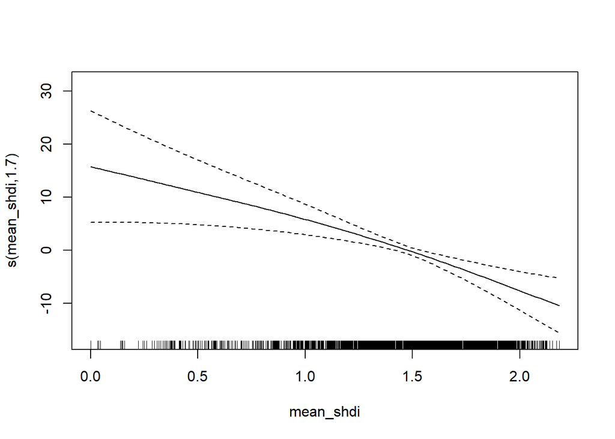

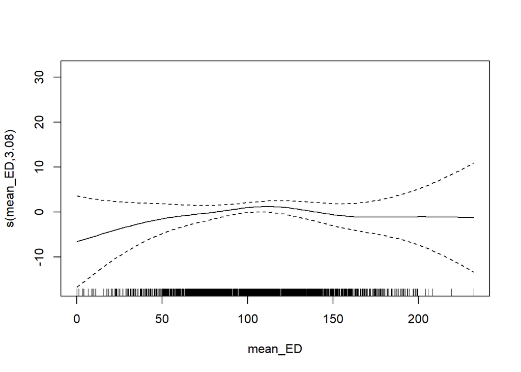

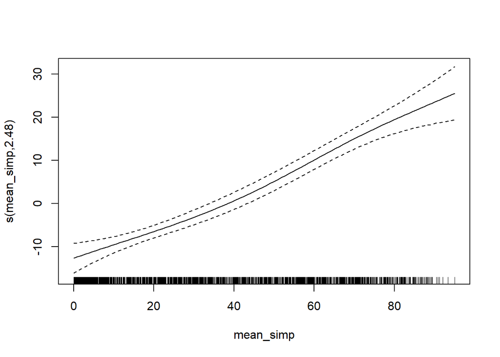

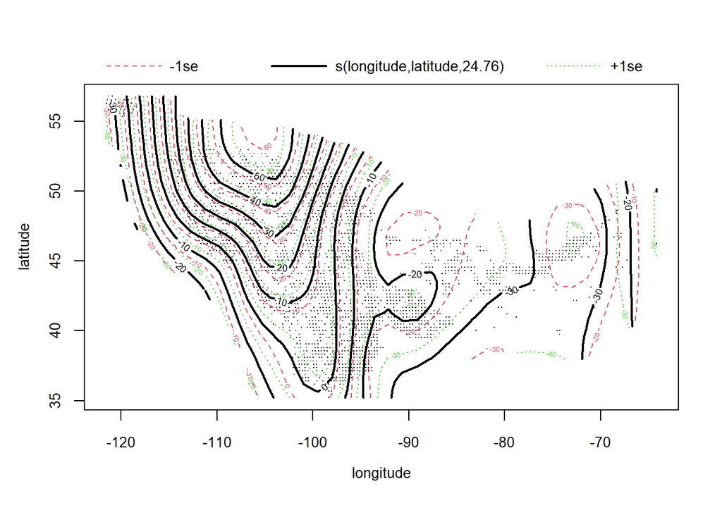

```r
plot(P1gam)
```

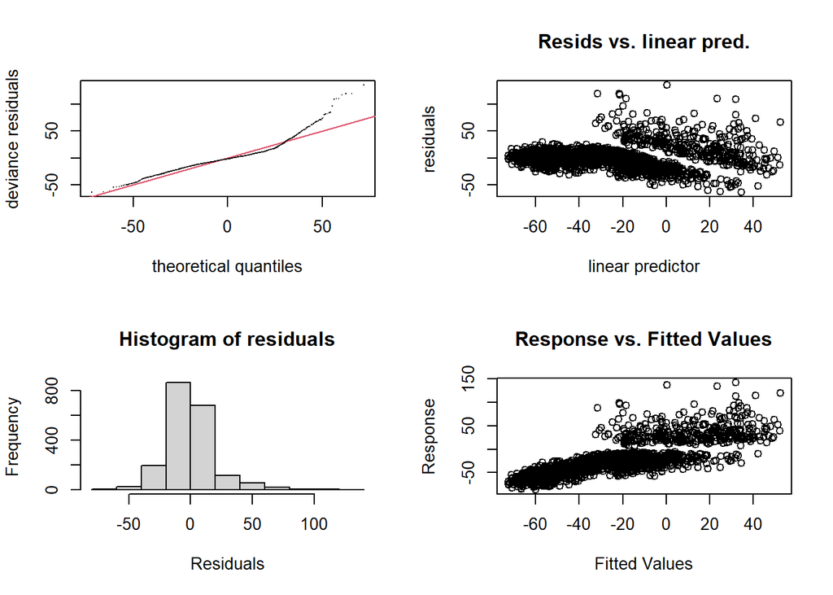

```
##
## Method: REML   Optimizer: outer newton
## full convergence after 5 iterations.
## Gradient range [-0.002616469,0.002083857]
## (score 8803.44 & scale 429.3217).
## Hessian positive definite, eigenvalue range [0.1023174,982.6375].
## Model rank =  57 / 57
##
## Basis dimension (k) checking results. Low p-value (k-index<1) may
## indicate that k is too low, especially if edf is close to k'.
##
##                          k'   edf k-index p-value
## s(mean_shdi)           9.00  1.70    1.00   0.555
## s(mean_ED)             9.00  3.08    1.00   0.440
## s(mean_simp)           9.00  2.48    0.94   0.005 **
## s(longitude,latitude) 29.00 24.76    0.68  <2e-16 ***
## ---
## Signif. codes:  0 '***' 0.001 '**' 0.01 '*' 0.05 '.' 0.1 ' ' 1
```

```r
gam.check(P1gam)
```

Simple model examine if abundance is a significant predictor in trends

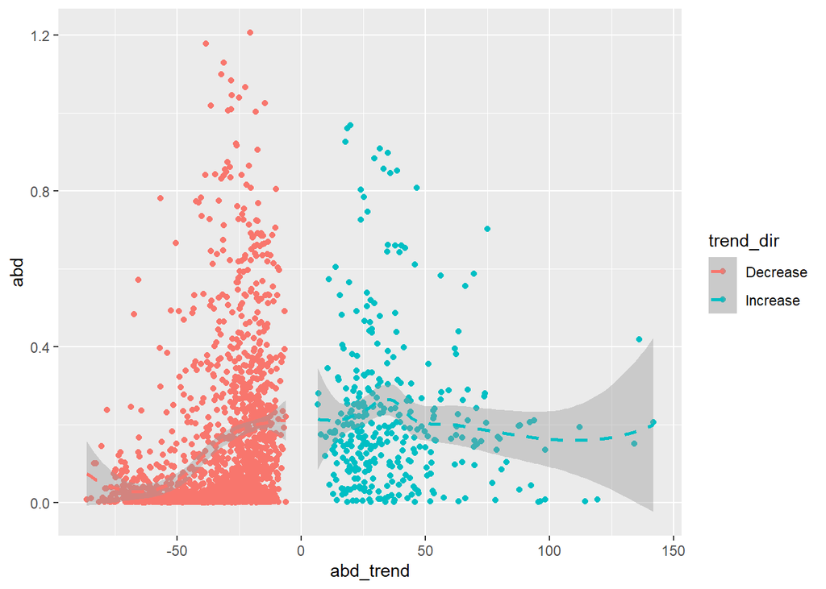

```r
ggplot(upsa_trd, aes(x = abd_trend, y = abd, color = trend_dir))+
  geom_point()+
geom_smooth(method = "loess", se = TRUE, linetype = "dashed")
```

```r
abdmodel <- gam(abd_trend ~ + s(abd) + s(longitude, latitude), data = upsa_trd, method = "REML")
summary(abdmodel)
```

```
##
## Family: gaussian
## Link function: identity
##
## Formula:
## abd_trend ~ +s(abd) + s(longitude, latitude)
##
## Parametric coefficients:
##             Estimate Std. Error t value Pr(>|t|)
## (Intercept) -22.2102     0.4915  -45.19   <2e-16 ***
## ---
## Signif. codes:  0 '***' 0.001 '**' 0.01 '*' 0.05 '.' 0.1 ' ' 1
##
## Approximate significance of smooth terms:
##                          edf Ref.df      F p-value
## s(abd)                 5.209  6.352  2.942 0.00832 **
## s(longitude,latitude) 26.226 28.506 61.254 < 2e-16 ***
## ---
## Signif. codes:  0 '***' 0.001 '**' 0.01 '*' 0.05 '.' 0.1 ' ' 1
##
## R-sq.(adj) =  0.568   Deviance explained = 57.4%
## -REML = 8915.3  Scale est. = 476.09    n = 1971
```

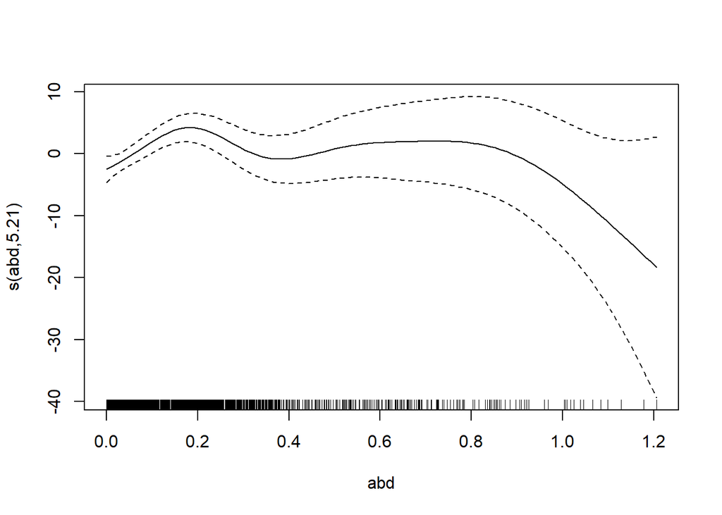

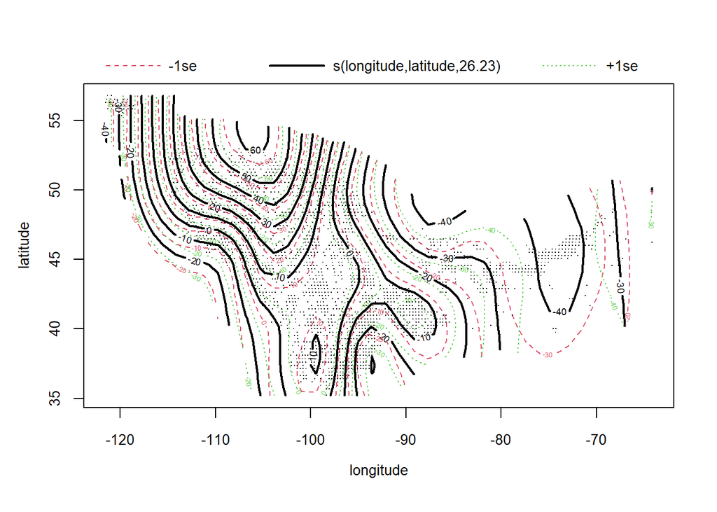

```r
plot(abdmodel)
```

```r
globalmodel <- gam(abd_trend ~ s(mean_shdi) + s(mean_ED) + s(mean_FLPI) + s(mean_GLPI) + s(simp_slope) + abd + s(longitude, latitude), data = upsa_trd, method = "REML")
summary(globalmodel)
```

```
##
## Family: gaussian
## Link function: identity
##
## Formula:
## abd_trend ~ s(mean_shdi) + s(mean_ED) + s(mean_FLPI) + s(mean_GLPI) +
##     s(simp_slope) + abd + s(longitude, latitude)
##
## Parametric coefficients:
##             Estimate Std. Error t value Pr(>|t|)
## (Intercept) -20.6651     0.9087 -22.741   <2e-16 ***
## abd         -10.1954     5.0962  -2.001   0.0456 *
## ---
## Signif. codes:  0 '***' 0.001 '**' 0.01 '*' 0.05 '.' 0.1 ' ' 1
##
## Approximate significance of smooth terms:
##                          edf Ref.df      F  p-value
## s(mean_shdi)           2.566  3.277  3.199   0.0193 *
## s(mean_ED)             4.843  6.006  8.484  < 2e-16 ***
## s(mean_FLPI)           4.531  5.543  6.130 6.87e-06 ***
## s(mean_GLPI)           2.179  2.709  1.072   0.2833
## s(simp_slope)          2.210  2.859  1.756   0.1706
## s(longitude,latitude) 25.981 28.411 60.028  < 2e-16 ***
## ---
## Signif. codes:  0 '***' 0.001 '**' 0.01 '*' 0.05 '.' 0.1 ' ' 1
##
## R-sq.(adj) =   0.59   Deviance explained = 59.9%
## -REML = 8863.1  Scale est. = 451.89    n = 1971
```

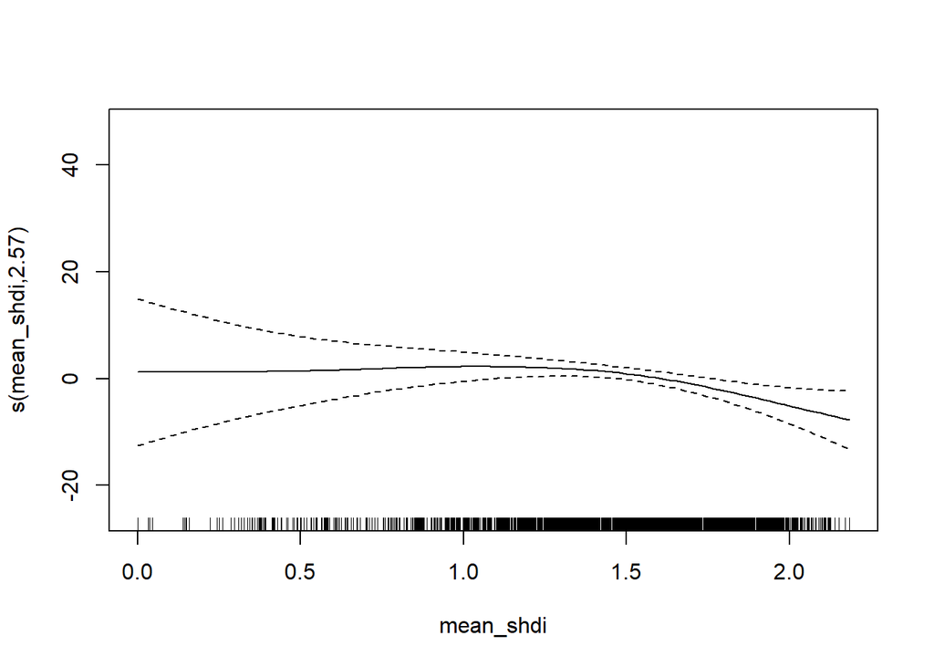

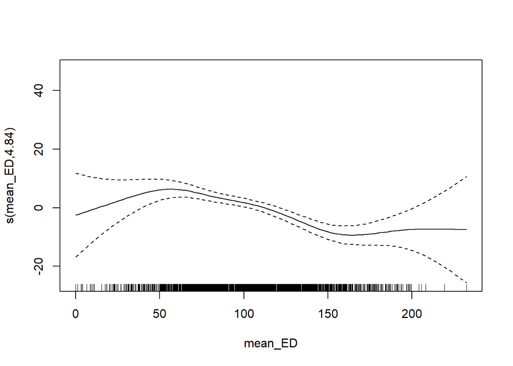

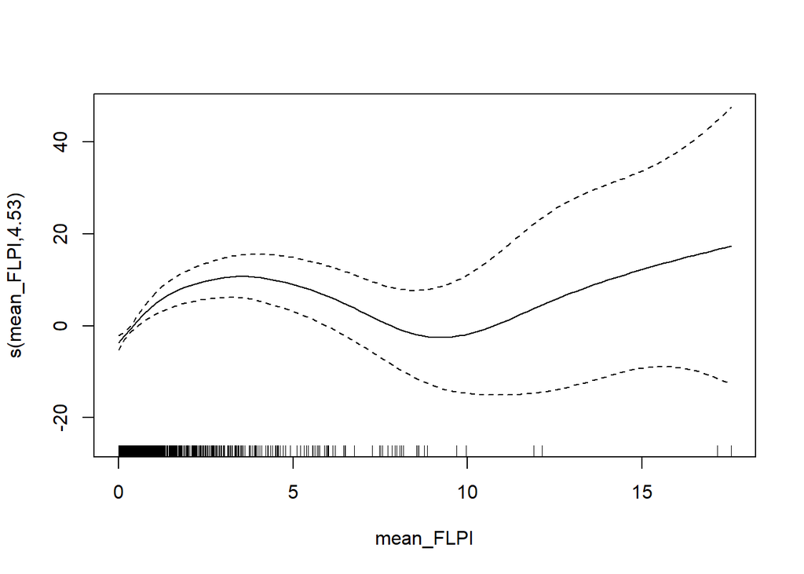

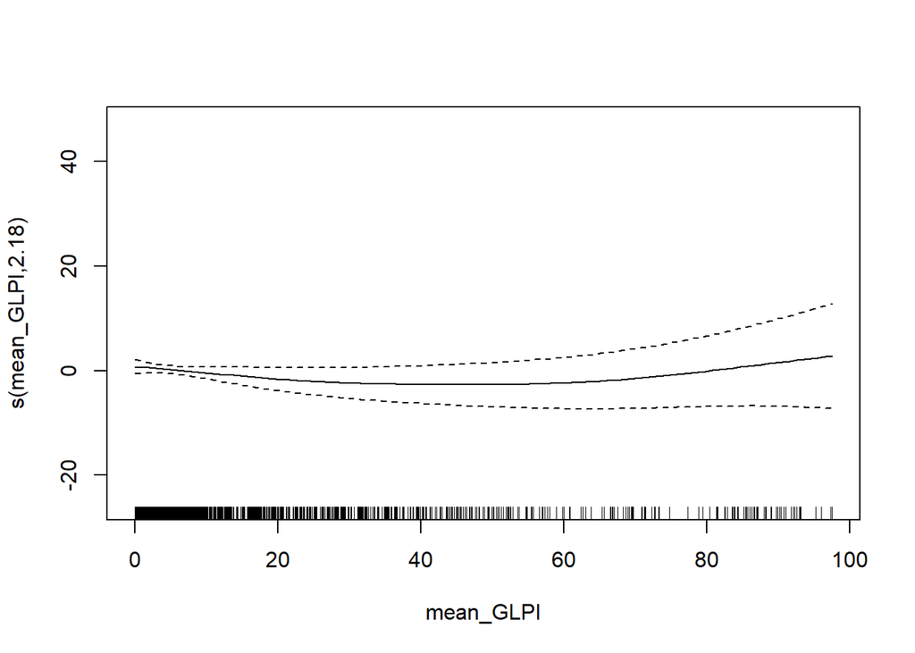

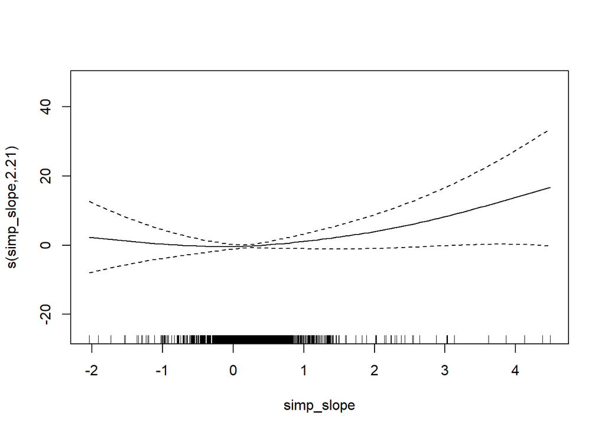

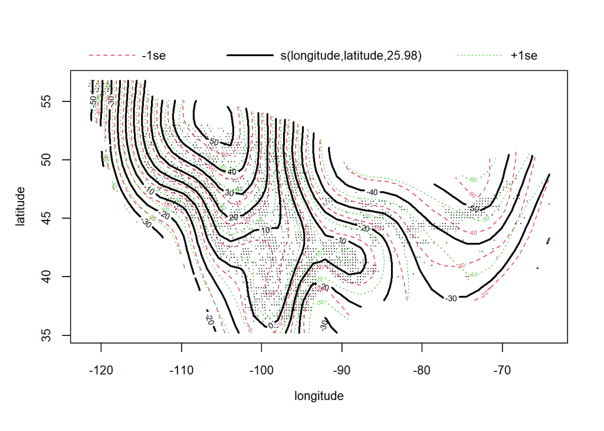

```r
plot(globalmodel)
```

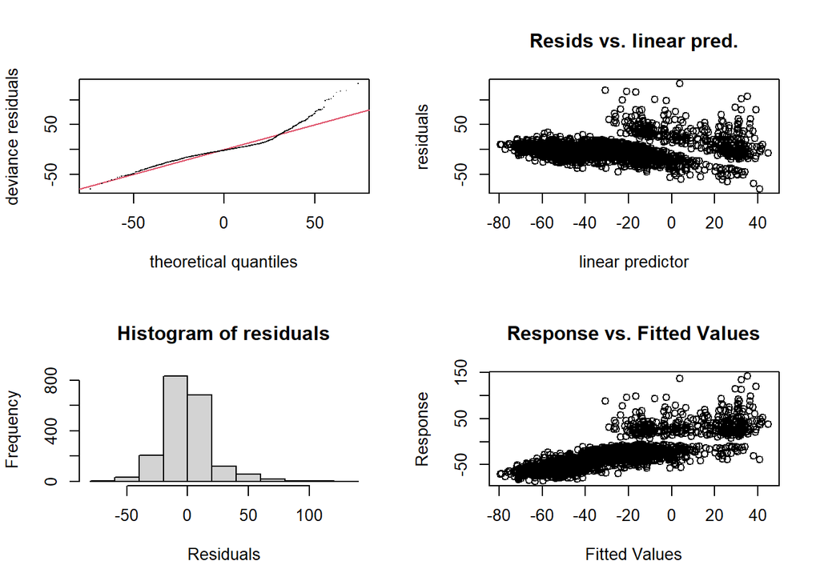

```
##
## Method: REML   Optimizer: outer newton
## full convergence after 6 iterations.
## Gradient range [-6.63228e-07,4.215752e-07]
## (score 8863.103 & scale 451.8861).
## Hessian positive definite, eigenvalue range [0.3103423,981.1565].
## Model rank =  76 / 76
##
## Basis dimension (k) checking results. Low p-value (k-index<1) may
## indicate that k is too low, especially if edf is close to k'.
##
##                          k'   edf k-index p-value
## s(mean_shdi)           9.00  2.57    1.01   0.645
## s(mean_ED)             9.00  4.84    0.98   0.275
## s(mean_FLPI)           9.00  4.53    1.03   0.845
## s(mean_GLPI)           9.00  2.18    0.96   0.025 *
## s(simp_slope)          9.00  2.21    0.99   0.305
## s(longitude,latitude) 29.00 25.98    0.67  <2e-16 ***
## ---
## Signif. codes:  0 '***' 0.001 '**' 0.01 '*' 0.05 '.' 0.1 ' ' 1
```

```r
gam.check(globalmodel)
```